# Matching Algorithms in Clinical Data

Workshop Exercise

# Objective

In this exercise, you will:

- Understand confounding in observational data
- Estimate propensity scores
- Perform matching using:
  - Propensity Score Matching (PSM)
  - Nearest Neighbor Matching
- Evaluate covariate balance

# Introduction

Matching is used in the context of estimating the causal effect of a binary treatment or exposure on an outcome while controlling for measured pre-treatment variables, typically confounding variables or variables prognostic of the outcome. The goal of matching is to produce covariate balance, that is, for the distributions of covariates in the two groups to be approximately equal to each other, as they would be in a successful randomized experiment. The importance of covariate balance is that it allows for increased robustness to the choice of model used to estimate the treatment effect; in perfectly balanced samples, a simple difference in means can be a valid treatment effect estimate.

# Environment Setup

We install and load:

- tidyverse → data manipulation and visualization
- MatchIt → performs matching algorithms
- cobalt → evaluates covariate balance

```r
# Install required packages
#install.packages(c('tidyverse', 'MatchIt', 'cobalt'))

# Import packages
library(tidyverse)
library(MatchIt)
library(cobalt)

#Setting a random seed ensures reproducibility
set.seed(123)
```

# Simulated Clinical Dataset

We first simulate a realistic clinical dataset of 1000 patients:

- Age, severity, comorbidity, sex → patient characteristics
- Treatment assignment is biased: Older, sicker patients are more likely to be treated
- Outcome depends on both treatment and severity

This creates confounding, mimicking real-world clinical data.

```r
n <- 1000

data <- tibble(age = rnorm(n, mean = 60, sd = 10),
  severity = sample(c("Low", "Medium", "High"), n, replace = TRUE),
  comorbidity = rbinom(n, 1, 0.4),
  sex = sample(c("Male", "Female"), n, replace = TRUE) )

# Encode severity numerically for modeling
data <- data %>%
  mutate(severity_num = case_when(
      severity == "Low" ~ 1,
      severity == "Medium" ~ 2,
      severity == "High" ~ 3) )

# Encode sex numerically for modeling
data <- data %>%
  mutate(sex_num = case_when(
      sex == "Female" ~ 1,
      sex == "Male" ~ 0) )

# Treatment assignment (biased!)
data <- data %>%
  mutate(treatment_prob = plogis(-5 + 0.05*age + 0.4*severity_num + 0.3*comorbidity),
         treatment = rbinom(n, 1, treatment_prob) )

# # Outcome depends on both treatment and severity
# data <- data %>%
#   mutate(outcome = rbinom(n, 1, plogis(-1 + 0.8*treatment - 0.7*severity_num)) )

# Outcome depends on treatment, age, severity_num, and comorbidity
data <- data %>%
  mutate(
    outcome = rbinom(n, 1,
      plogis(-2 +
             0.8*treatment +
             0.04*age +
             -0.7*severity_num +
             0.5*comorbidity))
  )

head(data)

write.table(x=data, file="./simulated_data_2.tsv",
            quote = FALSE, sep = "\t", row.names = FALSE, col.names = TRUE)
```

```r
data <- read.delim(file="./simulated_data_2.tsv")
head(data)
```

```
##        age severity comorbidity  sex severity_num sex_num treatment_prob
## 1 68.51246     High           1 Male            3       0      0.4814143
## 2 50.02488   Medium           0 Male            2       0      0.1546278
## 3 67.74895   Medium           0 Male            2       0      0.3073468
## 4 56.72525   Medium           1 Male            2       0      0.2565959
## 5 45.82043   Medium           1 Male            2       0      0.1667305
## 6 64.70800      Low           0 Male            1       0      0.2034937
##   treatment outcome
## 1         1       0
## 2         0       0
## 3         1       1
## 4         1       0
## 5         0       0
## 6         0       1
```

# Step 1: Explore Confounding Variable

We compare baseline characteristics between treated and untreated patients If these groups differ, we cannot directly compare outcomes.

```r
data %>%
  group_by(treatment) %>%
  summarise(
    mean_age = mean(age),
    mean_severity = mean(severity_num),
    comorbidity_rate = mean(comorbidity)
  )
```

```
## # A tibble: 2 × 4
##   treatment mean_age mean_severity comorbidity_rate
##       <int>    <dbl>         <dbl>            <dbl>
## 1         0     58.8          1.88            0.410
## 2         1     64.0          2.18            0.523
```

## Naïve Outcome Comparison

A naïve outcome comparison is simply comparing outcomes between treated and untreated groups without adjusting for differences between them. **Is the treatment effective?**

This comparison assumes that the two groups are comparable, but in observational data, they almost never are. So when we see a difference in outcomes, we don’t know if it’s due to the treatment or due to baseline differences.

```r
data %>%
  group_by(treatment) %>%
  summarise(outcome_rate = mean(outcome))
```

```
## # A tibble: 2 × 2
##   treatment outcome_rate
##       <int>        <dbl>
## 1         0        0.310
## 2         1        0.508
```

## Check Initial Imbalance

It’s always a good idea to view the initial imbalance in one’s data that matching is attempting to eliminate.

```r
# No matching; constructing a pre-match matchit object
m.out0 <- matchit(treatment ~ age + severity_num + comorbidity + sex_num,
                data = data, method = NULL, distance = "glm")
```

The first argument is a formula relating the treatment to the covariates that will be used in estimating the propensity score and for which balance is to be assessed. The data argument specifies the dataset where these variables exist. Typically, the method argument specifies the method of matching to be performed; here, we set it to NULL so we can assess balance prior to matching. The distance argument specifies the method for estimating the propensity score, computed as the predicted probability of being the treated group given the covariates; here, we set it to “glm” for generalized linear model, which implements logistic regression by default (see ?distance for other options).

Below we assess balance on the unmatched data using summary():

```r
# Checking balance prior to matching
summary(m.out0)
```

```
##
## Call:
## matchit(formula = treatment ~ age + severity_num + comorbidity +
##     sex_num, data = data, method = NULL, distance = "glm")
##
## Summary of Balance for All Data:
##              Means Treated Means Control Std. Mean Diff. Var. Ratio eCDF Mean
## distance            0.3292        0.2308          0.6575     1.5024    0.1957
## age                63.9843       58.7536          0.5606     1.0179    0.1494
## severity_num        2.1836        1.8750          0.3867     0.9399    0.1029
## comorbidity         0.5234        0.4099          0.2272          .    0.1135
## sex_num             0.5117        0.4906          0.0423          .    0.0211
##              eCDF Max
## distance       0.3114
## age            0.2445
## severity_num   0.1664
## comorbidity    0.1135
## sex_num        0.0211
##
## Sample Sizes:
##           Control Treated
## All           744     256
## Matched       744     256
## Unmatched       0       0
## Discarded       0       0
```

We can see severe imbalances as measured by the standardized mean differences (Std. Mean Diff.), variance ratios (Var. Ratio), and empirical cumulative distribution function (eCDF) statistics. Values of standardized mean differences and eCDF statistics close to zero and values of variance ratios close to one indicate good balance, and here many of them are far from their ideal values.

# Step 2: Matching

## Estimate Propensity Scores

A propensity score is the probability that a patient receives a treatment given their observed characteristics. It is typically estimated using logistic regression.

The key advantage is that it reduces many covariates into a single summary measure, allowing us to match patients based on this score rather than trying to match on each variable individually.

```r
ps_model <- glm(treatment ~ age + severity_num + comorbidity + sex_num,
                data = data, family = binomial)

data$propensity_score <- predict(ps_model, type = "response")

summary(data$propensity_score)
```

```
##    Min. 1st Qu.  Median    Mean 3rd Qu.    Max.
## 0.02702 0.14931 0.23423 0.25600 0.33621 0.78840
```

## Visualize Propensity Scores

This plot shows whether treated and control groups overlap. **Is there overlap between groups?**

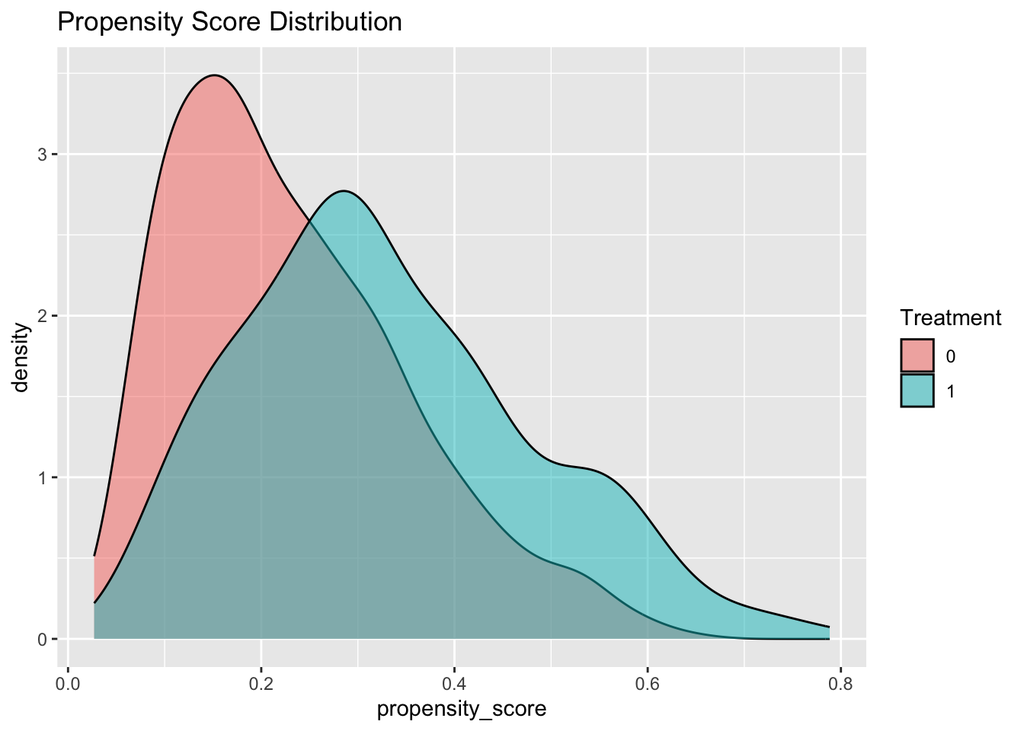

```r
ggplot(data, aes(x = propensity_score, fill = factor(treatment))) +
  geom_density(alpha = 0.5) +
  labs(fill = "Treatment", title = "Propensity Score Distribution")
```

## Perform Propensity Score Matching (PSM)

Now, matching can be performed. Here, we begin by briefly demonstrating 1:1 nearest neighbor (NN) matching on the propensity score. One by one, each treated unit is paired with an available control unit that has the closest propensity score to it. Any remaining control units are left unmatched and excluded from further analysis.

We use the same syntax as before, but this time specify method = “nearest” to implement nearest neighbor matching, again using a logistic regression propensity score. Many other arguments are available for tuning the matching method and method of propensity score estimation.

The matching outputs are contained in the psm_model object. Printing this object gives a description of the type of matching performed:

```r
psm_model <- matchit(treatment ~ age + severity_num + comorbidity + sex_num,
                     data = data,
                     method = "nearest",
                     distance = "glm")
psm_model
```

```
## A `matchit` object
##  - method: 1:1 nearest neighbor matching without replacement
##  - distance: Propensity score
##              - estimated with logistic regression
##  - number of obs.: 1000 (original), 512 (matched)
##  - target estimand: ATT
##  - covariates: age, severity_num, comorbidity, sex_num
```

# Step 3: Assessing the Quality of Matches

Although matching on the propensity score is often effective at eliminating differences between the treatment groups to achieve covariate balance, its performance in this regard must be assessed. If covariates remain imbalanced after matching, the matching is considered unsuccessful, and a different matching specification should be tried.

## Check Balance After Matching

```r
# Checking balance after NN matching
summary(psm_model, un = FALSE)
```

```
##
## Call:
## matchit(formula = treatment ~ age + severity_num + comorbidity +
##     sex_num, data = data, method = "nearest", distance = "glm")
##
## Summary of Balance for Matched Data:
##              Means Treated Means Control Std. Mean Diff. Var. Ratio eCDF Mean
## distance            0.3292        0.3184          0.0724     1.2922    0.0060
## age                63.9843       63.5011          0.0518     1.2413    0.0296
## severity_num        2.1836        2.1445          0.0490     0.9802    0.0130
## comorbidity         0.5234        0.5273         -0.0078          .    0.0039
## sex_num             0.5117        0.5391         -0.0547          .    0.0273
##              eCDF Max Std. Pair Dist.
## distance       0.0781          0.0738
## age            0.0742          0.7373
## severity_num   0.0195          0.9007
## comorbidity    0.0039          0.9620
## sex_num        0.0273          1.0081
##
## Sample Sizes:
##           Control Treated
## All           744     256
## Matched       256     256
## Unmatched     488       0
## Discarded       0       0
```

Next is a table of the sample sizes before and after matching. Ideally, unmatched units would be those far from the treated units and would require greater extrapolation were they to have been retained. We can visualize the distribution of propensity scores of those who were matched using plot() with type = “jitter”:

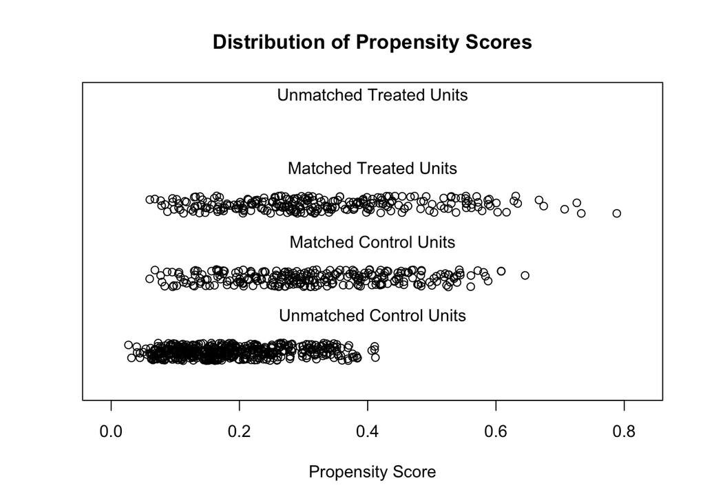

```r
plot(psm_model, type = "jitter", interactive = FALSE)
```

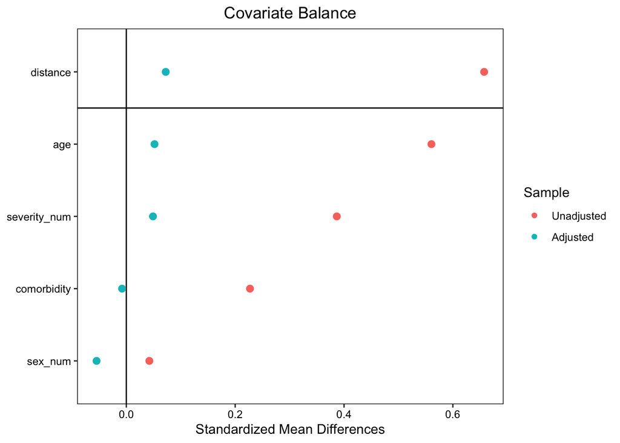

```r
#plot(psm_model, type = "density", interactive = FALSE,
#     which.xs = ~age + severity_num + comorbidity + sex_num)
love.plot(psm_model, binary = "std")
```

**Did the matching algorithm successfully improve comparability in our simulated data?**

# Trying a Different Matching Specification

Please try a different matching method or make other changes to the matching algorithm or distance specification. (**Hint:** For exploring other methods, visitx https://cran.r-project.org/web/packages/MatchIt/vignettes/matching-methods.html)

# Downstream analysis: Extract Matched Data

We can now extract the matched dataset and compare outcomes again.

```r
matched_data <- match.data(psm_model)
head(matched_data)
```

```
##         age severity comorbidity    sex severity_num sex_num treatment_prob
## 1  68.51246     High           1   Male            3       0      0.4814143
## 3  67.74895   Medium           0   Male            2       0      0.3073468
## 4  56.72525   Medium           1   Male            2       0      0.2565959
## 10 62.50922     High           1 Female            3       1      0.4074447
## 11 62.57004     High           0   Male            3       0      0.3381615
## 12 61.14575      Low           1   Male            1       0      0.2239642
##    treatment outcome propensity_score  distance weights subclass
## 1          1       0        0.5192669 0.5192669       1        1
## 3          1       1        0.2777332 0.2777332       1        2
## 4          1       0        0.2383875 0.2383875       1        3
## 10         0       1        0.4486019 0.4486019       1       21
## 11         1       0        0.3139839 0.3139839       1        4
## 12         0       0        0.2004797 0.2004797       1      182
```

```r
dim(matched_data)
```

```
## [1] 512  13
```

This is the dataset that should be used for analysis, as the matched groups are more comparable in terms of baseline characteristics. As a result, the estimated treatment effect should be more reliable and less biased by confounding.

```r
# Outcome After Matching
matched_data %>%
  group_by(treatment) %>%
  summarise(outcome_rate = mean(outcome))
```

```
## # A tibble: 2 × 2
##   treatment outcome_rate
##       <int>        <dbl>
## 1         0        0.309
## 2         1        0.508
```

## Sources:

- https://dlab.berkeley.edu/news/introduction-propensity-score-matching-matchit
- https://cran.r-project.org/web/packages/MatchIt/vignettes/MatchIt.html
- https://cran.r-project.org/web/packages/MatchIt/vignettes/matching-methods.html